# Modeling Hospitalizations

Tino Schneidewind

2024-10-03

### This documents serves to determine adequat modeling paramteters for my Distributed Lagged (Non-Linear) Model DLNM for foehn and hospitalzations

#### We start of with generalized linear models with non linear parameters before we continue with distributed lagged models

### General Linear Models glm

```r
library(viridisLite); library(dlnm); library(splines); library(ggplot2); library(viridis); library(Epi); library(tsModel); library(mgcv); library(lubridate)
```

To reduce processing speed, the data will be shortened to two years of Chur, and from hereon called “data_short”. Rows with NAs wil be excluded.

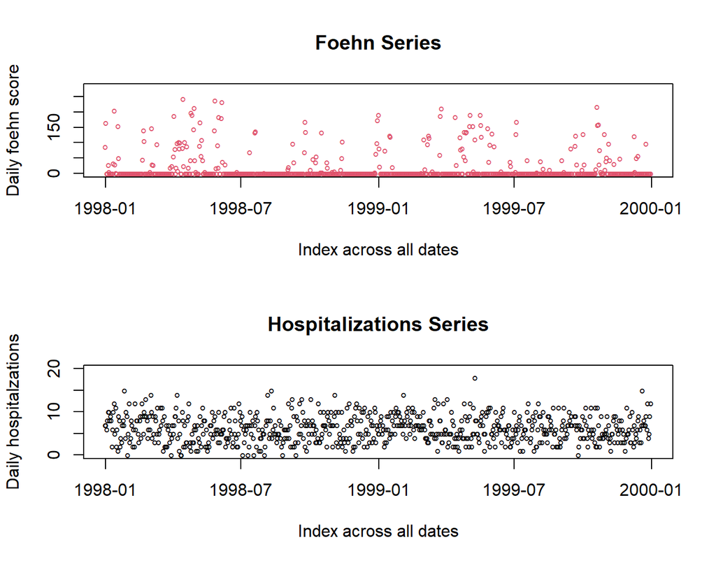

Now lets try to fit a model to the whole foehn series to predict hospitalizations (of the shortened data set).

```r
# lets start with a model that believes foehn to be the sole contributor
mnone <- glm(all ~ f_id, data_short, family=poisson)
ci.exp(mnone, subset = "f_id")
```

```
##      exp(Est.)      2.5%    97.5%
## f_id  1.000204 0.9995704 1.000838
```

A very simple model shows a very small association of hospitalization through foehn. As a next step, the model will predict hospitalizations based on the date (linear trend) and based on the month (seasonality). And finally, both affects combined.

```r
# linear trend
mlin <- glm(all ~ date, data_short, family=poisson)
ci.exp(mlin, subset = "date")
```

```
##      exp(Est.)      2.5%    97.5%
## date 0.9999698 0.9998309 1.000109
```

```r
# seasonality
mmonth <- glm(all ~factor(month), data_short, family = poisson)

# yearly trend + seasonality
mmonthinyear <- glm(all ~ factor(month)*factor(Year), data_short, family=poisson)
```

The risk from foehn may not be equal in all months. This can be implemented by using non-linear functions such as spline.

```r
# 5 degrees of freedom for 2 years of data
spltime <- bs(data_short$date, df=5*2)
mspline <- glm(all ~ spltime, data_short, family=poisson)
```

Lest plot the different models and see how they are able to predict the hospitalizations.

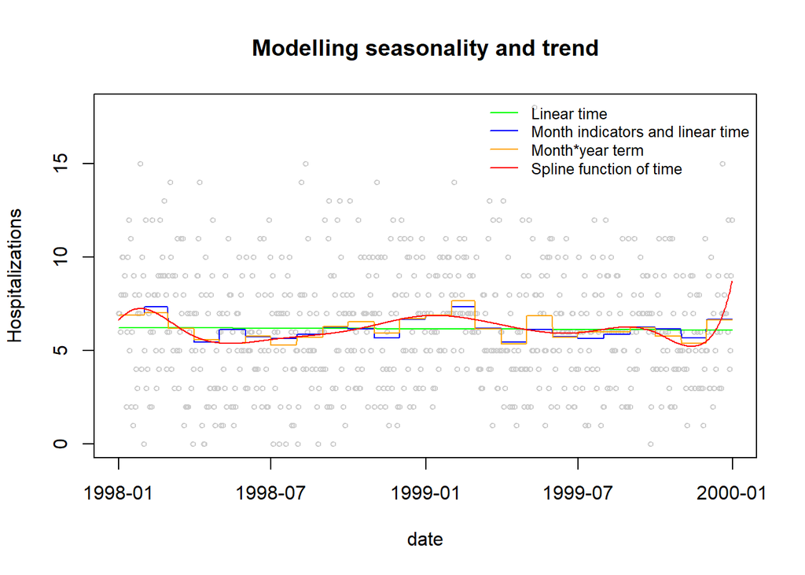

Now lets update the model using foehn as a linear term.

```r
# update the model with f_id
mlin <- update(mlin, .~ . + f_id)
mmonth <- update(mmonth, .~ . + f_id)
mmonthinyear <- update(mmonthinyear, .~ . + f_id)
mspline <- update(mspline, .~ . + f_id)

# extract CI
ci.exp(mlin, subset = "f_id")
```

```
##      exp(Est.)      2.5%    97.5%
## f_id  1.000196 0.9995615 1.000831
```

```r
ci.exp(mmonth, subset = "f_id")
```

```
##      exp(Est.)      2.5%    97.5%
## f_id  1.000392 0.9997293 1.001055
```

```r
ci.exp(mmonthinyear, subset = "f_id")
```

```
##      exp(Est.)      2.5%    97.5%
## f_id  1.000399 0.9997271 1.001072
```

```r
ci.exp(mspline, subset = "f_id")
```

```
##      exp(Est.)     2.5%    97.5%
## f_id  1.000444 0.999786 1.001102
```

```r
# comparing the models
AIC(mnone, mlin, mmonth, mmonthinyear, mspline)
```

```
##              df      AIC
## mnone         2 3768.124
## mlin          3 3769.973
## mmonth       13 3756.043
## mmonthinyear 25 3769.642
## mspline      12 3751.001
```

But not only foehn and time (trend, seasonality) can influence hospitalizations. A typical confounder is temperature, which can lead to short term variation of hospitalizations. Lets plot temperature against hospitalizations to see the association and fit a polynomial regression to it.

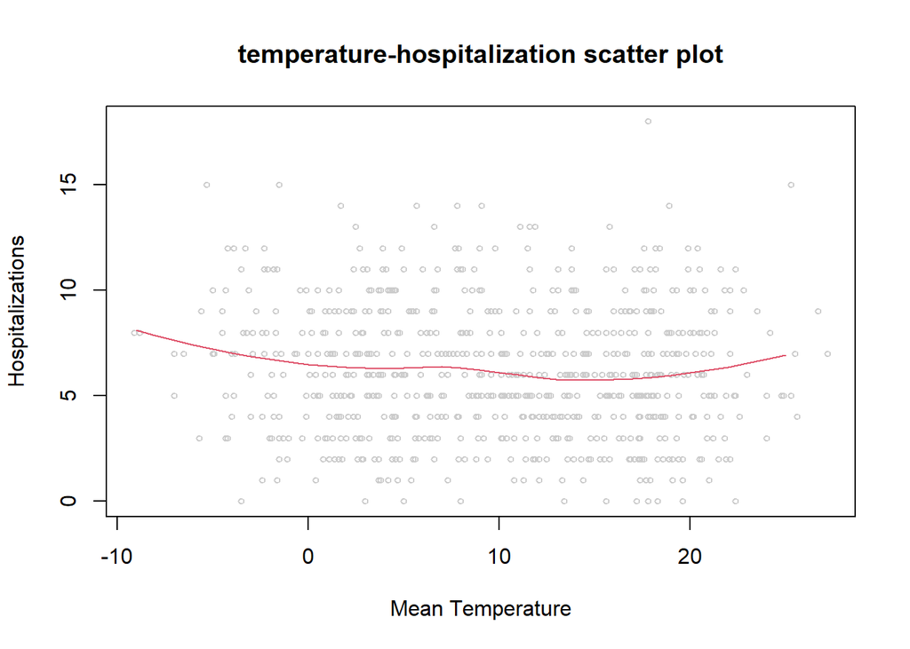

Now lets add temperature to our model using a slpine function.

```r
spltmean <- ns(data_short$temp, df=3)
mtmean <- glm(all ~ f_id + spltime + dow + spltmean, data_short, family=poisson)
```

For the first time, foehn is modeled to be attenuating to hospitalizations.

```r
AIC(mspline, mtmean)
```

```
##         df      AIC
## mspline 12 3751.001
## mtmean  21 3601.670
```

Through adding temperature to out model, the AIC drastically improved.

Lets investigate the individual components of our model.

```r
drop1(mtmean, test = "LRT")
```

```
## Single term deletions
##
## Model:
## all ~ f_id + spltime + dow + spltmean
##          Df Deviance    AIC     LRT  Pr(>Chi)
## <none>        1001.4 3601.7
## f_id      1   1001.6 3599.8   0.133  0.715103
## spltime  10   1041.3 3621.6  39.890 1.771e-05 ***
## dow       6   1156.1 3744.3 154.642 < 2.2e-16 ***
## spltmean  3   1015.1 3609.3  13.643  0.003434 **
## ---
## Signif. codes:  0 '***' 0.001 '**' 0.01 '*' 0.05 '.' 0.1 ' ' 1
```

In this model, we still have overdispersion and auto-correlation. We can adjust our model to account for this by changing the family to “quasi Poisson”.

```r
overdisp <- update(mtmean, family=quasipoisson)
summary(overdisp)$dispersion
```

```
## [1] 1.303994
```

```r
ci.exp(mtmean, subset="f_id")
```

```
##      exp(Est.)      2.5%  97.5%
## f_id  0.999863 0.9991266 1.0006
```

```r
ci.exp(overdisp, subset="f_id")
```

```
##      exp(Est.)      2.5%    97.5%
## f_id  0.999863 0.9990221 1.000705
```

The confidence interval has increased as a result! The CI of the for overdispersion adjusted model can be interpreted as follows: A 1 unit increase in the foehn score is associated with a decrease in the relative risk of 0.01369 %. And consequently, a 100 unit increase leads to a 1.369 % decrease in the relative risk of hospitalisation. A shift from a no foehn day to full foehn day (288 difference) decreases relative risk by 3.945 %.

Lets investigate the autocorrelation of the data.

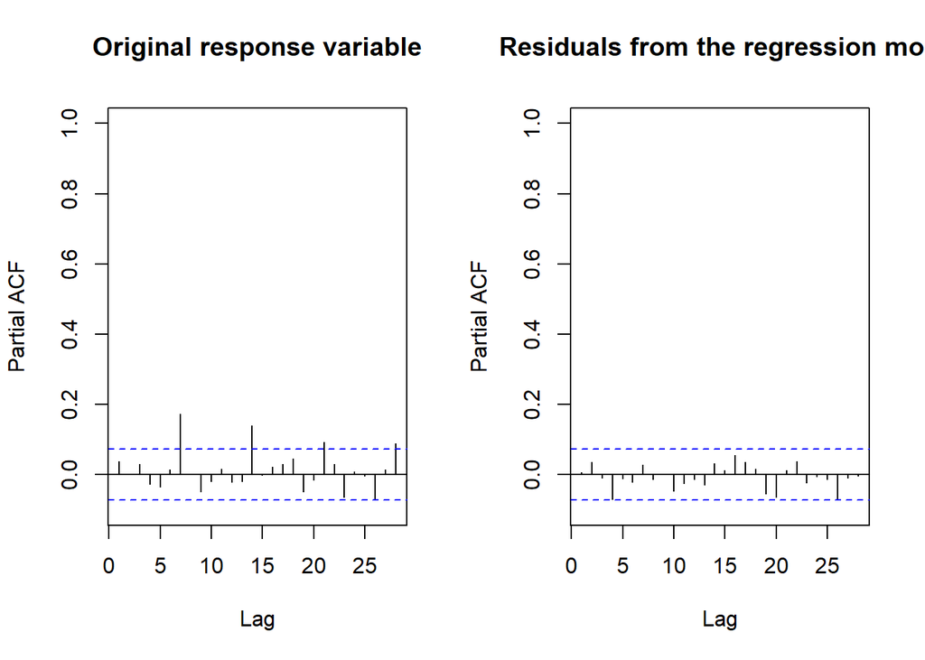

In our adjusted model, there is no autocorrelation anymore.

### Distributed lagged models

#### We begin to fit a distributed lag model DLM to our data to account for the time shifted effect of heat (foehn and temperature) on hospitalizations. Here we still assume linearity

Lagged effects can be implemented in the model using the crossbasis() function. First we assume the variable to have a linear effect on the response variable, but the structure of the lag is modified to be unconstrained and a spline.

```r
cb_f_int <- crossbasis(data_short$f_id,
                       lag = 5,
                       argvar = list(fun = "lin"),
                       arglag = list(fun = "integer"))

cb_f_spl <- crossbasis(data_short$f_id,
                       lag = 5,
                       argvar = list(fun = "lin"),
                       arglag = list(fun = "ns", knots = c(1,3)))
```

These two crossbasis functions can now be updated into the previous model that accounted for overdispersion. By doing so, the exposure now is potentially complex while the estimation is still a standard regression.

```r
mod_cb_f_int <- update(overdisp,  .~.-f_id+cb_f_int, na.action = "na.exclude")
summary(mod_cb_f_int)[1]
```

```
## $call
## glm(formula = all ~ spltime + dow + spltmean + cb_f_int, family = quasipoisson,
##     data = data_short, na.action = "na.exclude")
```

```r
mod_cb_f_spl <- update(overdisp,  .~.-f_id+cb_f_spl, na.action = "na.exclude")
summary(mod_cb_f_spl)[1]
```

```
## $call
## glm(formula = all ~ spltime + dow + spltmean + cb_f_spl, family = quasipoisson,
##     data = data_short, na.action = "na.exclude")
```

Investigating the CI of these models is hard, as there is a CI for every lag. Therefore we utilize the crosspred() function. We reduce the lag distance to 0.2 so that we are able to visualize a smoother curve further down the line (for integer this is not possible). As a reference for the prediction, in linear models, cen=0 by default.

```r
cp_f_int <- crosspred(cb_f_int, mod_cb_f_int, at = 0:288)

cp_f_spl <- crosspred(cb_f_spl, mod_cb_f_spl, at = 0:288, bylag = 0.2)
```

For these predictions, a foehn and lag-specific increase can be defined and extracted. Here increase of 100 foehn score and lag of 1. Additionally, the overall cumulative risk along the lag period at a specific exposure can be extracted.

```r
# exposure and lag
cp_f_int$matfit["100", "lag1"]
```

```
## [1] 0.007845786
```

```r
# cumulative risk at specific exposure
cp_f_spl$allRRfit["288"]
```

```
##       288
## 0.8940692
```

### Distributed lagged non linear models

#### Here we also get rid of the assumption of a linear influence of the exposure to the response.

```r
# crossbasis
cb_f_ns <- crossbasis(data_short$f_id,
                       lag = 5,
                       argvar = list(fun = "ns", knots = c(1,3)),
                       arglag = list(fun = "ns", knots = c(1,3)))

# model
mo_f_ns <- glm(all ~ cb_f_ns + spltmean + ns(date, 7*2) + dow,
              family=quasipoisson(), data_short)

# prediction
cp_f_ns <- crosspred(cb_f_ns, mo_f_ns, at = 0:288, bylag = 0.2, cen = 0)
```

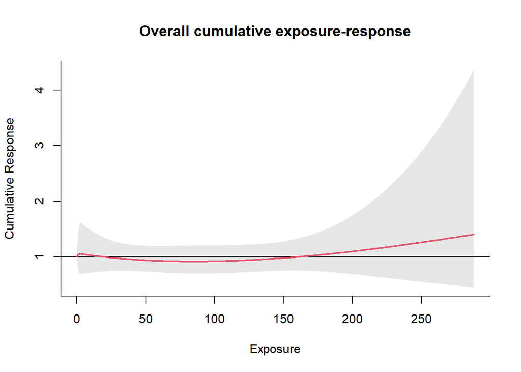

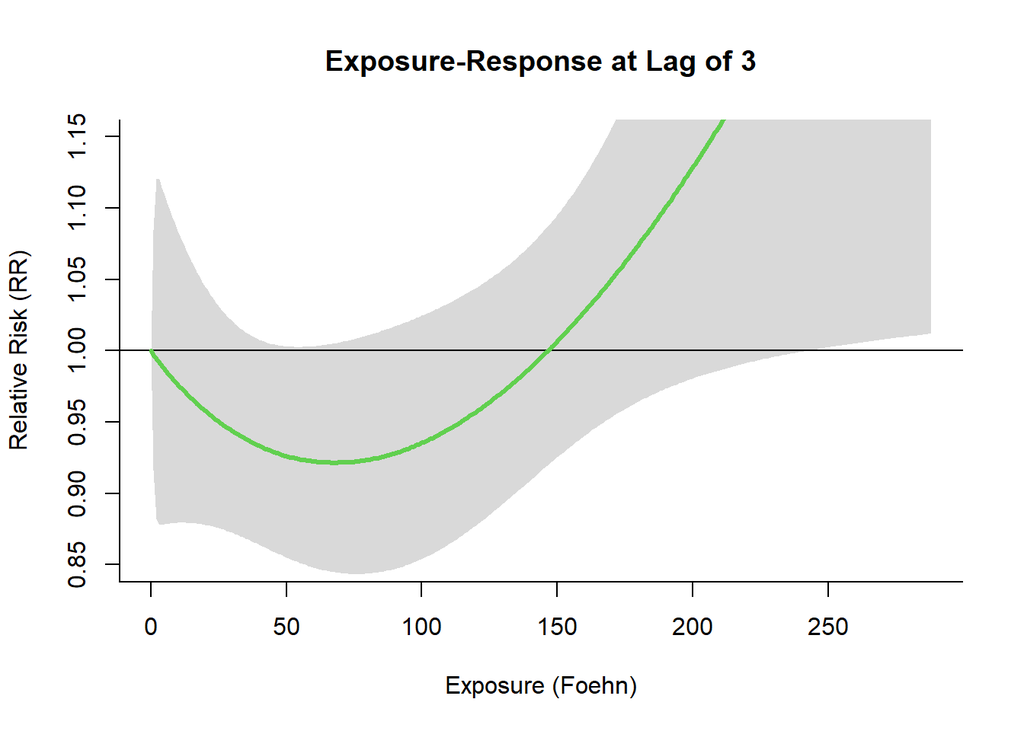

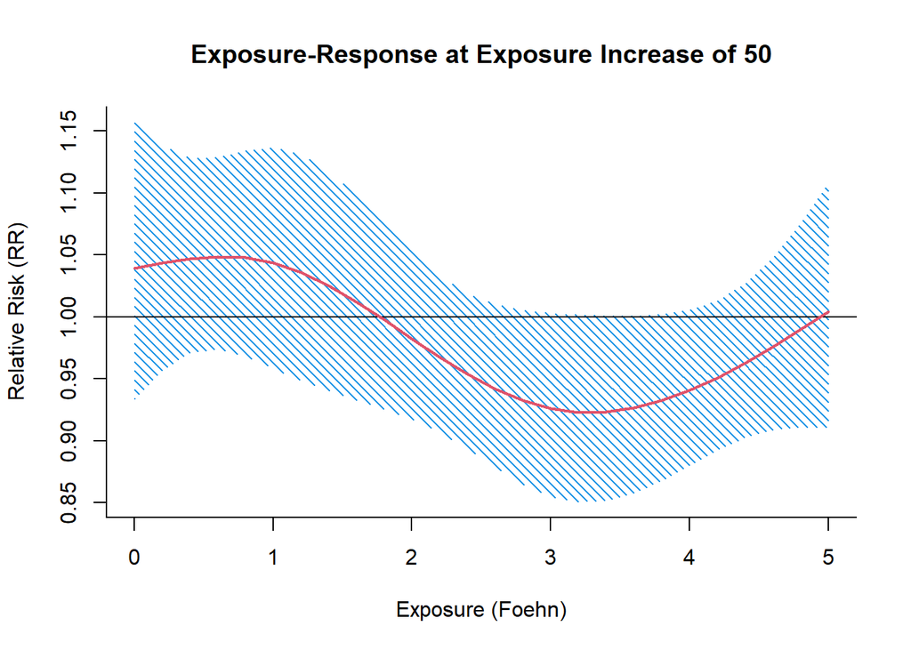